# Atlas Visual Sulawesi Selatan: Kemiskinan dan Pengangguran, 2023-2025

Grafik statistik yang jujur, terprogram, dan teruji

Penulis

Kelompok 5: Ilfani Magfirli dan Rizka Magfira

Diterbitkan

12 Oktober 2026

**Kode**

```r
# Jalankan dari folder proyek (buka nama-tim.Rproj atau pakai quarto render dari folder ini)
source("R/theme_tim.R")
source("R/fungsi_grafik.R")
source("R/autoplot.R")

# ---- PARAMETER DEMO: ubah satu nilai, lalu render ulang ----
tahun_acuan <- 2025

dat  <- muat_data()
peta <- muat_peta(dat, tahun_acuan)
```

# Pesan utama

**Kemiskinan turun di seluruh kabupaten/kota Sulawesi Selatan, tetapi jarak antarwilayah tetap lebar, dan kemiskinan serta pengangguran tidak bergerak searah.**

- **Turun merata.** Kemiskinan turun di **24 dari 24** kabupaten/kota antara 2023 dan 2025. Rata-rata sederhana 24 wilayah turun dari 9,33% menjadi 8,14%. Penurunan terjadi di seluruh wilayah pada kedua periode (2023-2024 dan 2024-2025).
- **Jarak antarwilayah lebar.** Pada 2025, kemiskinan tertinggi ada di Pangkajene Dan Kepulauan (11,60%) dan terendah di Makassar (4,43%), atau sekitar 2,6 kali lipat.
- **Kemiskinan dan pengangguran berbeda.** Wilayah yang lebih miskin cenderung memiliki TPT lebih rendah. Hubungan itu lemah sampai sedang dan sebagian ditopang oleh Kota Makassar, sehingga keduanya perlu dibaca sebagai dua persoalan yang berbeda.
- **Pola yang tampak bukan kebetulan.** Dalam uji lineup, 7 dari 12 pengamat mengenali panel data asli, jauh di atas peluang acak 1 dari 20.

# Data dan metode

- **Indikator utama:** persentase penduduk miskin. **Pendamping:** Tingkat Pengangguran Terbuka (TPT).
- **Cakupan:** 24 kabupaten/kota Sulawesi Selatan, 2023-2025. **Sumber:** BPS; batas wilayah dari geoBoundaries (ADM2).
- Seluruh grafik dibuat dari kode. Tema memakai `theme_tim()` buatan tim, tanpa paket tema siap pakai.
- Konvensi warna: biru = kemiskinan, oranye = TPT, hijau = sorotan.
- Pembanding “rata-rata” pada profil adalah rata-rata sederhana 24 wilayah, bukan angka resmi provinsi (yang dibobot penduduk).

# Makeover grafik resmi

**Grafik asli:** “Perkembangan Jumlah dan Persentase Penduduk Miskin, Maret 2019 - Maret 2025” (BPS, Berita Resmi Statistik No. 43/07/73/Th. XXIX, 25 Juli 2025).

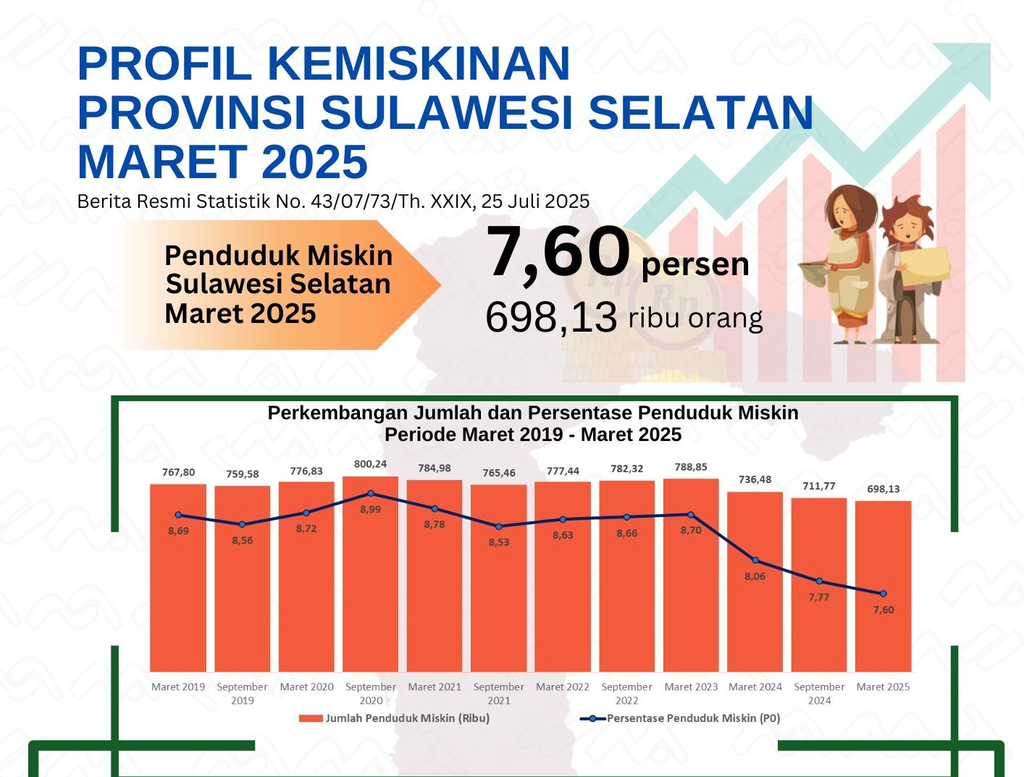

**Masalah yang ditemukan**

[output not shown]

**Rancangan ulang**

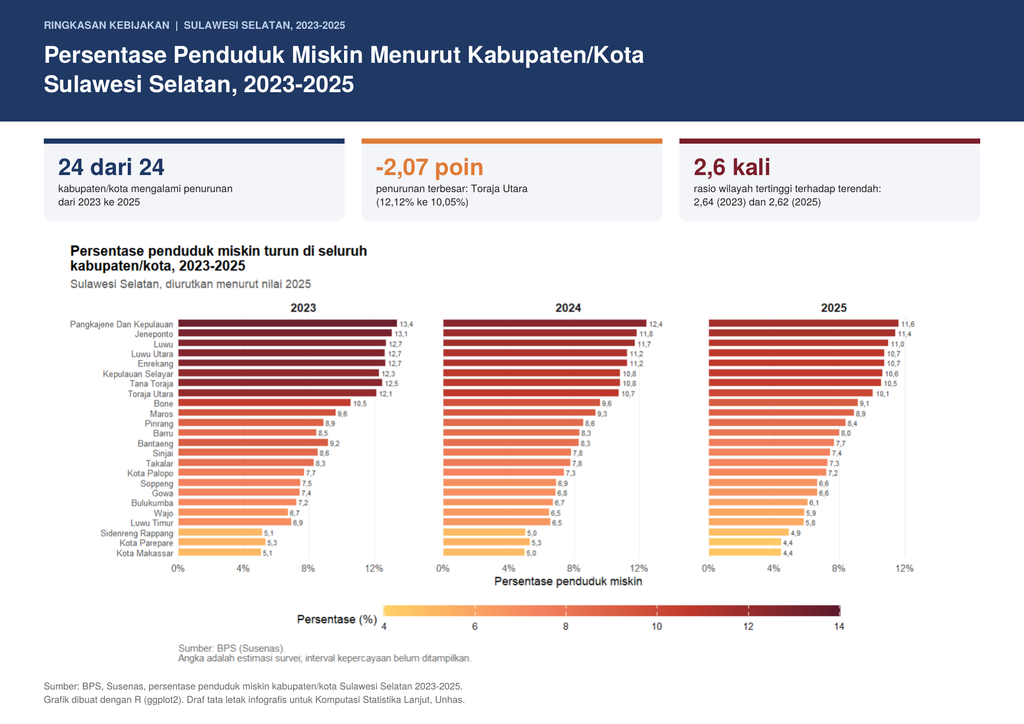

# Galeri grafik statistik

## Sebaran per tahun

**Kode**

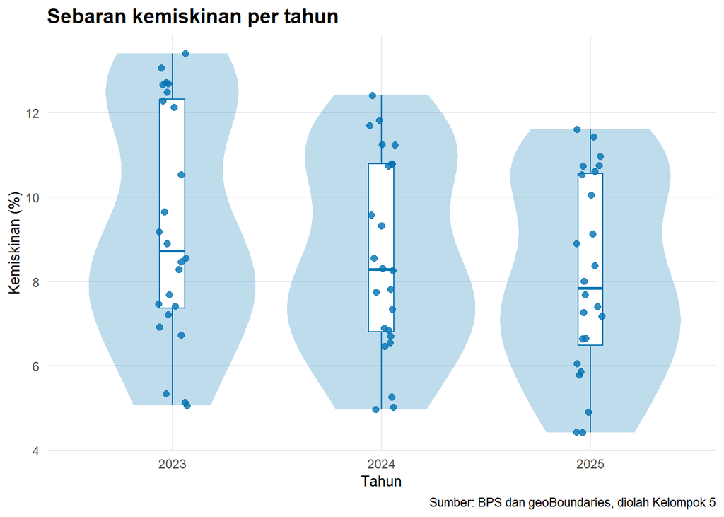

```r
plot_sebaran(dat, kemiskinan, judul = "Sebaran kemiskinan per tahun", label_y = "Kemiskinan (%)")
```

## Tren 24 wilayah

**Kode**

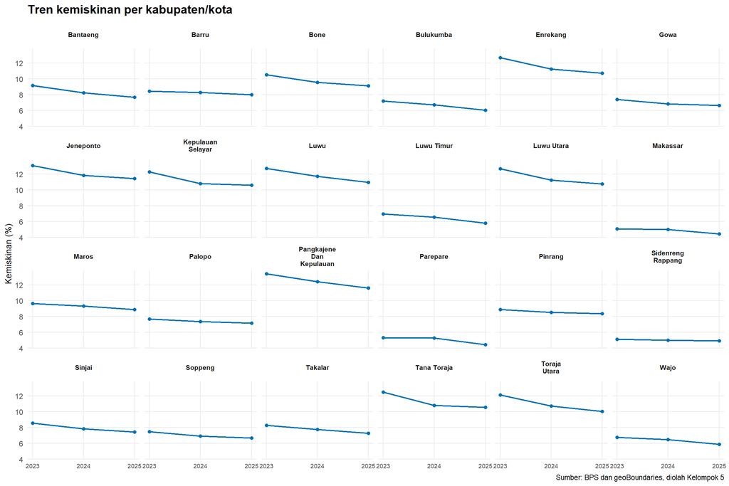

```r
plot_tren(dat, kemiskinan, judul = "Tren kemiskinan per kabupaten/kota", label_y = "Kemiskinan (%)")
```

**Kode**

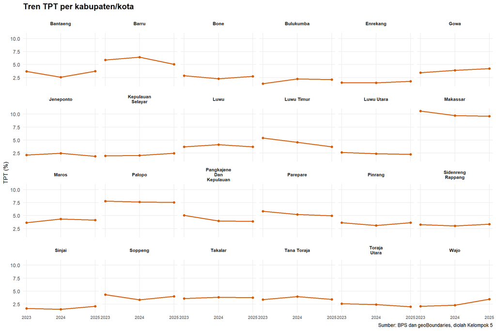

```r
plot_tren(dat, tpt, warna = oranye, judul = "Tren TPT per kabupaten/kota", label_y = "TPT (%)")
```

## Kemiskinan dan TPT

**Kode**

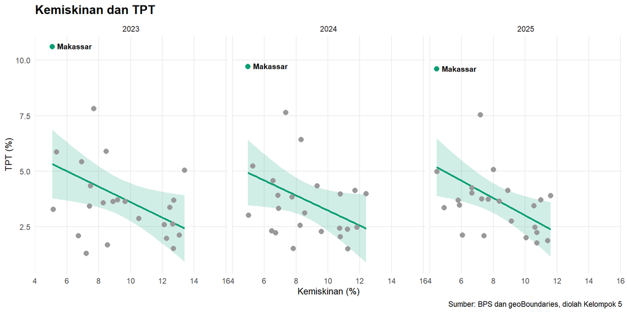

```r
plot_scatter(dat, kemiskinan, tpt, judul = "Kemiskinan dan TPT",
             label_x = "Kemiskinan (%)", label_y = "TPT (%)")
```

Korelasi kemiskinan dan TPT antarwilayah, per tahun

| Tahun | r, 24 wilayah | p, 24 wilayah | r, tanpa Makassar | p, tanpa Makassar |
| --- | --- | --- | --- | --- |
| 2023 | -0,45 | 0,028 | -0,32 | 0,134 |
| 2024 | -0,40 | 0,054 | -0,25 | 0,249 |
| 2025 | -0,50 | 0,012 | -0,39 | 0,067 |

## Perubahan per wilayah

**Kode**

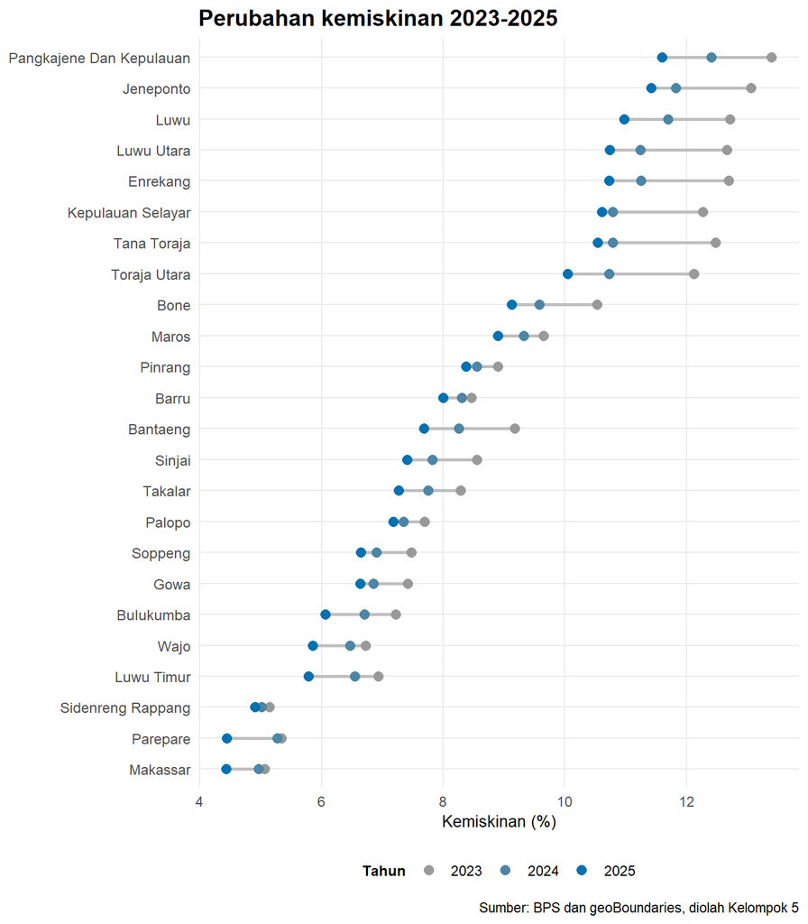

```r
plot_dumbbell(dat, kemiskinan, judul = "Perubahan kemiskinan 2023-2025", label_x = "Kemiskinan (%)")
```

## Komposisi multipanel

**Kode**

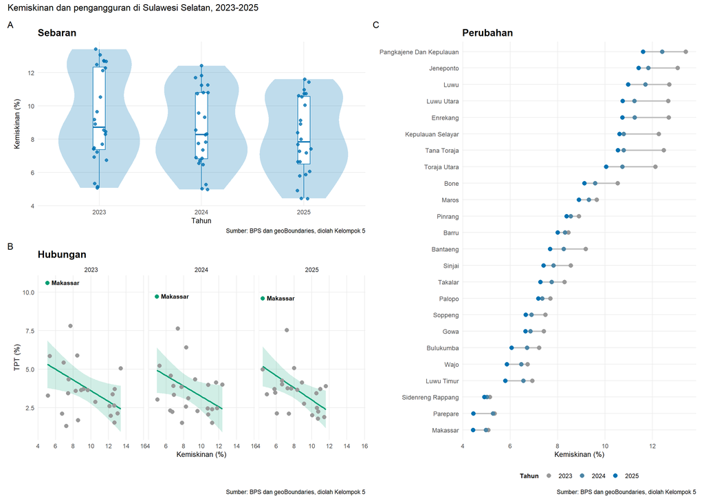

```r
((plot_sebaran(dat, kemiskinan, label_y = "Kemiskinan (%)", judul = "Sebaran") /
  plot_scatter(dat, kemiskinan, tpt, label_x = "Kemiskinan (%)", label_y = "TPT (%)", judul = "Hubungan")) |
  plot_dumbbell(dat, kemiskinan, judul = "Perubahan", label_x = "Kemiskinan (%)")) +
  plot_layout(widths = c(1.4, 1)) +
  plot_annotation(tag_levels = "A",
                  title = "Kemiskinan dan pengangguran di Sulawesi Selatan, 2023-2025")
```

# Peta koroplet dan uji buta warna

**Kode**

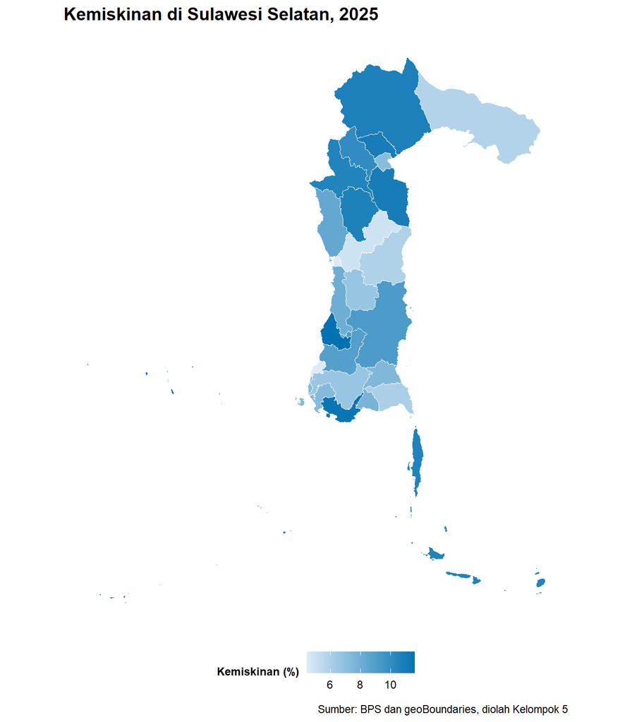

```r
pal <- palet_peta()
peta_kor(peta, kemiskinan, pal, paste("Kemiskinan di Sulawesi Selatan,", tahun_acuan), "Kemiskinan (%)")
```

**Kode**

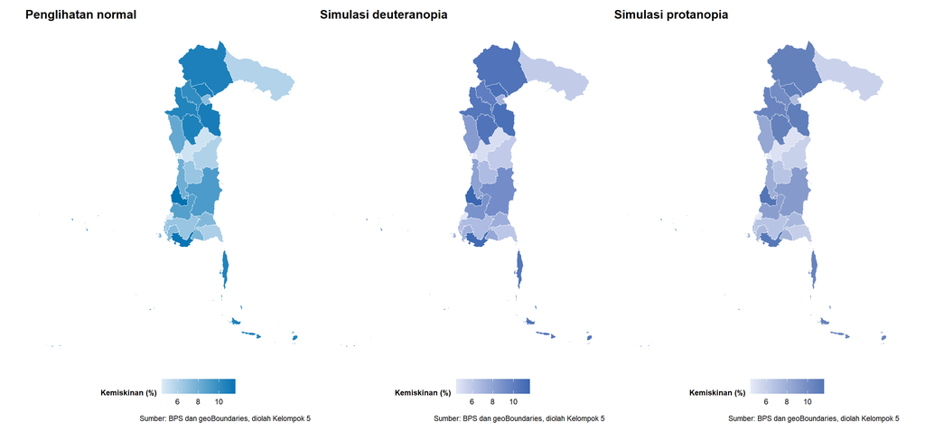

```r
uji_butawarna(peta, kemiskinan, pal, "Kemiskinan (%)")
```

Pada simulasi deuteranopia dan protanopia, urutan terang ke gelap tetap jelas, sehingga skema warna dinyatakan lolos.

# 24 profil kabupaten/kota

Seluruh profil dibuat dari satu perintah. Untuk demo, ubah `tahun_acuan` pada chunk `setup` lalu jalankan:

**Kode**

```r
buat_semua_profil(dat, peta, tahun_acuan)
```

**Kode**

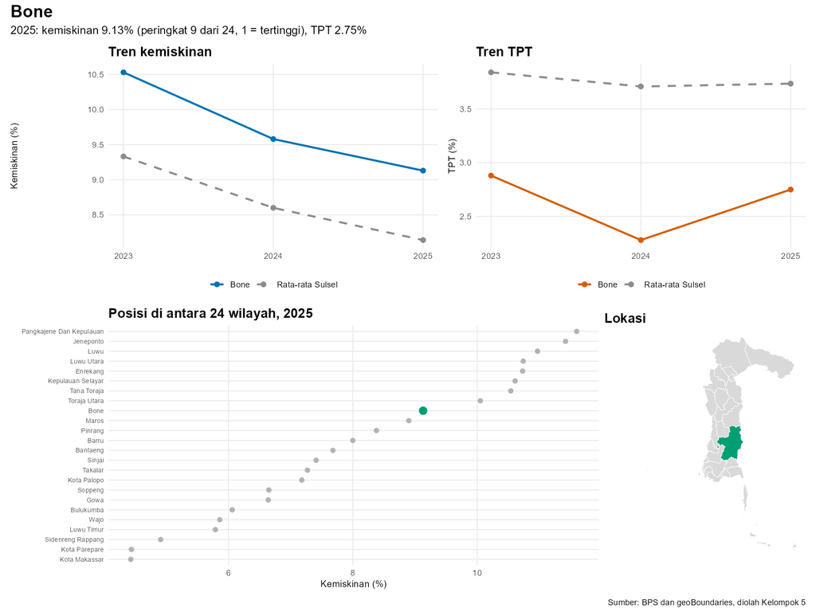

```r
contoh <- "keluaran/profil/profil_Bone.png"
if (file.exists(contoh)) knitr::include_graphics(contoh)
```

# Ketidakpastian: SK bootstrap 95%

**Kode**

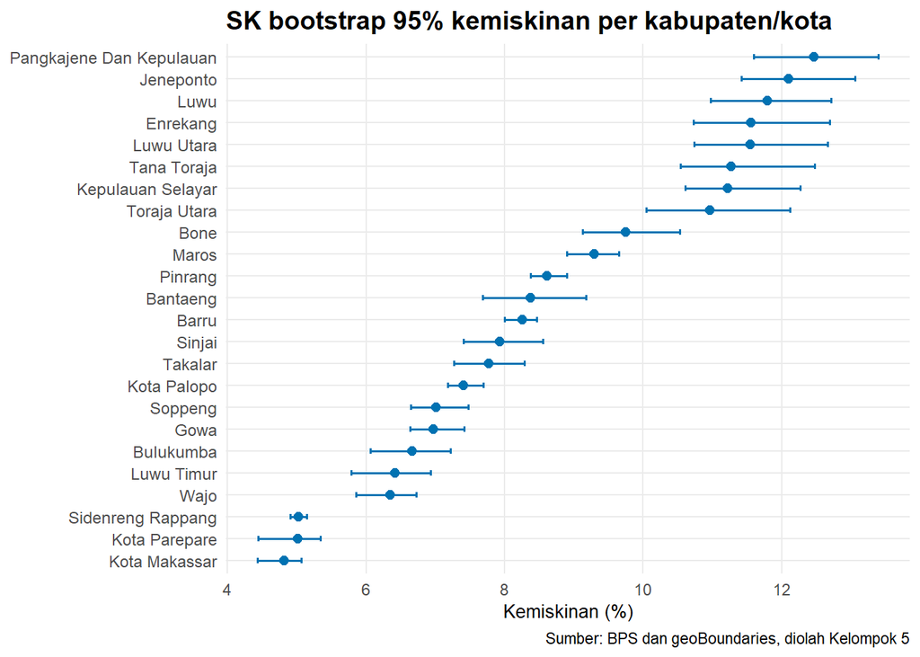

```r
# Hasil bootstrap disimpan di keluaran/hasil_bootstrap.rds (dibuat oleh R/bootstrap.R)
if (file.exists("keluaran/hasil_bootstrap.rds")) {
  analisis <- analisis_tim(
    bootstrap = readRDS("keluaran/hasil_bootstrap.rds"),
    lineup    = if (file.exists("keluaran/hasil_lineup.rds")) readRDS("keluaran/hasil_lineup.rds") else NULL
  )
  autoplot(analisis)
} else {
  cat("MENYUSUL: simpan hasil bootstrap di keluaran/hasil_bootstrap.rds\n")
}
```

**Kode**

```r
if (exists("analisis")) {
  cek <- dat |>
    group_by(Wilayah = wilayah) |>
    summarise(mn = min(kemiskinan), mx = max(kemiskinan), .groups = "drop") |>
    inner_join(analisis$bootstrap, by = "Wilayah")
  sama <- sum(abs(cek$Batas_bawah - cek$mn) < 1e-9 & abs(cek$Batas_atas - cek$mx) < 1e-9)
  cat(sprintf("**Catatan keterbatasan:** setiap wilayah hanya memiliki %d nilai tahunan. Pada %d dari %d wilayah, batas bawah dan atas selang sama persis dengan nilai terendah dan tertinggi dari ketiga tahun. Untuk rata-rata dari n = 3, bootstrap persentil memang menghasilkan batas itu, sehingga selang ini lebih tepat dibaca sebagai rentang antartahun daripada ukuran ketidakpastian sampling.\n",
              n_distinct(dat$tahun), sama, nrow(cek)))
}
```

**Catatan keterbatasan:** setiap wilayah hanya memiliki 3 nilai tahunan. Pada 21 dari 21 wilayah, batas bawah dan atas selang sama persis dengan nilai terendah dan tertinggi dari ketiga tahun. Untuk rata-rata dari n = 3, bootstrap persentil memang menghasilkan batas itu, sehingga selang ini lebih tepat dibaca sebagai rentang antartahun daripada ukuran ketidakpastian sampling.

*Tafsiran.* Selang dihitung dengan bootstrap persentil 95% dengan **B = 1.999** pengulangan (seed 2026; kode pada `R/bootstrap.R`). Yang di-resample, dengan pengembalian, adalah tiga nilai tahunan (2023-2025) tiap wilayah. Selang **paling lebar** dimiliki Toraja Utara, Enrekang, Tana Toraja: kemiskinan di wilayah itu berubah paling besar antartahun. Selang **paling sempit** dimiliki Sidenreng Rappang, Barru, Kota Palopo, yang kemiskinannya relatif stabil. Di bagian tengah urutan, banyak selang yang saling tumpang tindih, sehingga selisih kecil antara dua wilayah yang peringkatnya berdekatan **tidak dapat dibaca sebagai perbedaan nyata**. Sebaliknya, kelompok tertinggi (Pangkajene Dan Kepulauan, Jeneponto, Luwu) dan kelompok terendah (Kota Makassar, Kota Parepare, Sidenreng Rappang) terpisah jelas dan tidak berhimpit. Seperti dicatat di atas, selang ini mencerminkan variasi antartahun dan bukan ketidakpastian sampling survei, sehingga perlu dibaca dengan hati-hati.

# Hasil lineup (inferensi visual)

Lineup 20 panel: 1 panel data asli dan 19 panel data permutasi (H0: TPT tidak berhubungan dengan kemiskinan).

**Kode**

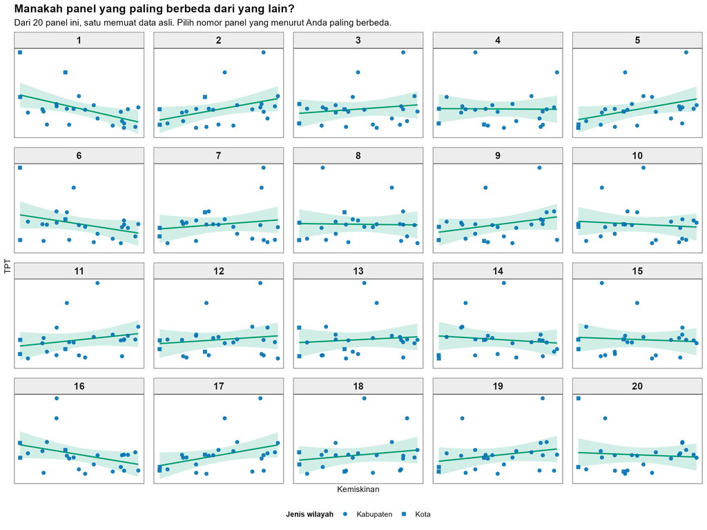

```r
if (file.exists("keluaran/lineup_20panel.png")) knitr::include_graphics("keluaran/lineup_20panel.png")
```

**Kode**

```r
if (file.exists("keluaran/hasil_lineup.rds")) {
  hl <- readRDS("keluaran/hasil_lineup.rds")
  K <- hl$jumlah_pengamat
  x <- hl$jumlah_benar
  p_visual <- 1 - pbinom(x - 1, size = K, prob = 1/20)   # dihitung ulang dari K dan x
  cat(sprintf("Panel data asli ada di nomor **%d**. Dari **%d** pengamat, **%d** (%.1f%%) memilih panel asli, sedangkan peluang menebak benar secara acak hanya 1/20 = 5%%. P-value visual = **%.2g**.\n",
              hl$posisi_panel_asli, K, x, 100 * x / K, p_visual))
} else {
  cat("MENYUSUL: simpan hasil lineup di keluaran/hasil_lineup.rds\n")
}
```

Panel data asli ada di nomor **1**. Dari **12** pengamat, **7** (58.3%) memilih panel asli, sedangkan peluang menebak benar secara acak hanya 1/20 = 5%. P-value visual = **4.9e-07**.

*Tafsiran:* pada tingkat signifikansi 5%, hipotesis nol (TPT tidak berhubungan dengan kemiskinan, sehingga panel asli tidak dapat dibedakan dari 19 panel acak) ditolak: pengamat mampu mengenali panel asli jauh di atas peluang acak. Hasil ini tidak menyatakan seberapa kuat hubungannya, dan pola pada panel asli dapat dipengaruhi pencilan (Kota Makassar dengan TPT tertinggi). Jumlah pengamat (12) memenuhi syarat minimal 10.

# Metode `autoplot()`

`autoplot()` adalah fungsi generik dari ggplot2. Tim menulis metode S3 `autoplot.analisis_tim()` untuk objek berkelas `analisis_tim` (konstruktor `analisis_tim()`, lihat `R/autoplot.R`).

**Kode**

```r
if (exists("analisis")) {
  print(class(analisis))
  print(getS3method("autoplot", "analisis_tim"))
  analisis            # metode print
}
```

```
[1] "analisis_tim"
function (object, judul = "SK bootstrap 95% kemiskinan per kabupaten/kota",
    label_y = "Kemiskinan (%)", ...)
{
    ggplot(object$bootstrap, aes(x = reorder(Wilayah, Rata_rata),
        y = Rata_rata)) + geom_errorbar(aes(ymin = Batas_bawah,
        ymax = Batas_atas), colour = biru, width = 0.25, linewidth = 0.6) +
        geom_point(colour = biru, size = 2.2) + coord_flip() +
        labs(title = judul, x = NULL, y = label_y, caption = sumber) +
        theme_tim()
}
```

```
Objek analisis_tim
  Wilayah          : 24
  Rata-rata (min-maks): 4.82 - 12.47
  Hasil lineup     : ada
```

*Dispatch:* `autoplot(analisis)` memanggil `autoplot.analisis_tim()` karena kelas objeknya `analisis_tim`. Grafik yang dihasilkan sama dengan bagian ketidakpastian di atas.

# Lampiran: deklarasi penggunaan AI

Tim memakai Claude (Anthropic) sebagai asisten untuk: menyusun dan memperbaiki kode R (fungsi grafik, peta, profil otomatis, lineup, kerangka atlas), menyusun draf pesan utama dan tafsiran grafik, menulis deskripsi checkpoint, dan menyusun infografis kebijakan dari kode (skripnya tersedia di repositori). Seluruh kode dijalankan dan diperiksa oleh tim, angka pada tafsiran dihitung dari data, dan kedua anggota dapat menjelaskan kodenya. Pemilihan data, kesimpulan, dan isi laporan merupakan tanggung jawab tim.